# Red Wine

Yoon-gu Hwang

July 5, 2015

```r
library(ggplot2)
library(GGally)
library(gridExtra)
library(psych)
library(dplyr)
library(scales)
library(memisc)
theme_set(theme_minimal(20))
```

# Univariate Plot Section

```r
setwd('~/repos/nanodgreep3')
wdf <- read.csv('wineQualityReds.csv')
wdf <- wdf[,-1] # Get rid of unused column : 'X'
dim(wdf)
```

```
## [1] 1599   12
```

```r
names(wdf)
```

```
##  [1] "fixed.acidity"        "volatile.acidity"     "citric.acid"
##  [4] "residual.sugar"       "chlorides"            "free.sulfur.dioxide"
##  [7] "total.sulfur.dioxide" "density"              "pH"
## [10] "sulphates"            "alcohol"              "quality"
```

```r
str(wdf)
```

```
## 'data.frame':    1599 obs. of  12 variables:
##  $ fixed.acidity       : num  7.4 7.8 7.8 11.2 7.4 7.4 7.9 7.3 7.8 7.5 ...
##  $ volatile.acidity    : num  0.7 0.88 0.76 0.28 0.7 0.66 0.6 0.65 0.58 0.5 ...
##  $ citric.acid         : num  0 0 0.04 0.56 0 0 0.06 0 0.02 0.36 ...
##  $ residual.sugar      : num  1.9 2.6 2.3 1.9 1.9 1.8 1.6 1.2 2 6.1 ...
##  $ chlorides           : num  0.076 0.098 0.092 0.075 0.076 0.075 0.069 0.065 0.073 0.071 ...
##  $ free.sulfur.dioxide : num  11 25 15 17 11 13 15 15 9 17 ...
##  $ total.sulfur.dioxide: num  34 67 54 60 34 40 59 21 18 102 ...
##  $ density             : num  0.998 0.997 0.997 0.998 0.998 ...
##  $ pH                  : num  3.51 3.2 3.26 3.16 3.51 3.51 3.3 3.39 3.36 3.35 ...
##  $ sulphates           : num  0.56 0.68 0.65 0.58 0.56 0.56 0.46 0.47 0.57 0.8 ...
##  $ alcohol             : num  9.4 9.8 9.8 9.8 9.4 9.4 9.4 10 9.5 10.5 ...
##  $ quality             : int  5 5 5 6 5 5 5 7 7 5 ...
```

```r
levels(factor(wdf$quality))
```

```
## [1] "3" "4" "5" "6" "7" "8"
```

```r
summary(wdf)
```

```
##  fixed.acidity   volatile.acidity  citric.acid    residual.sugar
##  Min.   : 4.60   Min.   :0.1200   Min.   :0.000   Min.   : 0.900
##  1st Qu.: 7.10   1st Qu.:0.3900   1st Qu.:0.090   1st Qu.: 1.900
##  Median : 7.90   Median :0.5200   Median :0.260   Median : 2.200
##  Mean   : 8.32   Mean   :0.5278   Mean   :0.271   Mean   : 2.539
##  3rd Qu.: 9.20   3rd Qu.:0.6400   3rd Qu.:0.420   3rd Qu.: 2.600
##  Max.   :15.90   Max.   :1.5800   Max.   :1.000   Max.   :15.500
##    chlorides       free.sulfur.dioxide total.sulfur.dioxide
##  Min.   :0.01200   Min.   : 1.00       Min.   :  6.00
##  1st Qu.:0.07000   1st Qu.: 7.00       1st Qu.: 22.00
##  Median :0.07900   Median :14.00       Median : 38.00
##  Mean   :0.08747   Mean   :15.87       Mean   : 46.47
##  3rd Qu.:0.09000   3rd Qu.:21.00       3rd Qu.: 62.00
##  Max.   :0.61100   Max.   :72.00       Max.   :289.00
##     density             pH          sulphates         alcohol
##  Min.   :0.9901   Min.   :2.740   Min.   :0.3300   Min.   : 8.40
##  1st Qu.:0.9956   1st Qu.:3.210   1st Qu.:0.5500   1st Qu.: 9.50
##  Median :0.9968   Median :3.310   Median :0.6200   Median :10.20
##  Mean   :0.9967   Mean   :3.311   Mean   :0.6581   Mean   :10.42
##  3rd Qu.:0.9978   3rd Qu.:3.400   3rd Qu.:0.7300   3rd Qu.:11.10
##  Max.   :1.0037   Max.   :4.010   Max.   :2.0000   Max.   :14.90
##     quality
##  Min.   :3.000
##  1st Qu.:5.000
##  Median :6.000
##  Mean   :5.636
##  3rd Qu.:6.000
##  Max.   :8.000
```

The average quality is 5.6 and median of quality is 6.0. About 75% of wines have quality score under or equal to 6. About 75% of wines have fixed acidity less than 10.0. About 75% of wines have residual sugar less than 2.6, but its maximum value, 15.5 is very high(i.e. very sweet). All wines have similar density, from 0.99 to 1.00.

```
## stat_bin: binwidth defaulted to range/30. Use 'binwidth = x' to adjust this.
```

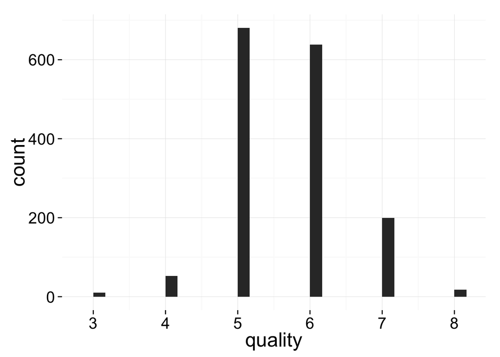

```r
qplot(x = quality, data = wdf)
```

Quality have all integer values. Most wines have 5 or 6 score value. It can be categorized as three grades.

```r
wdf['taste'] <- "GD"
wdf$taste[wdf$quality == 3 | wdf$quality == 4] <- "NG"
wdf$taste[wdf$quality == 5 | wdf$quality == 6] <- "GD"
wdf$taste[wdf$quality == 7 | wdf$quality == 8] <- "EX"
wdf$taste <- factor(wdf$taste, levels=c("NG", "GD", "EX"))

wdf['taste.detail'] <- factor(wdf$quality, levels = c("3", "4", "5", "6", "7", "8"))
```

- 3 and 4 : Not Good(NG)
- 5 and 6 : Good(GD)
- 8 and 7 : Excellent(EX)

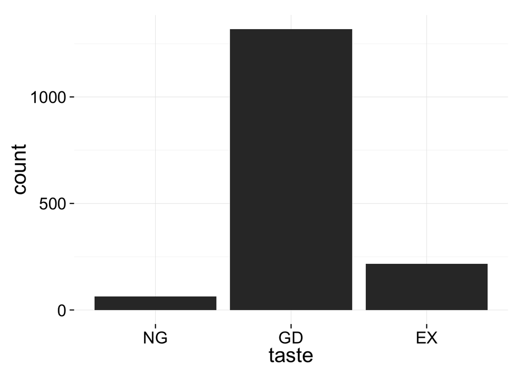

```r
qplot(x = taste, data = wdf)
```

```r
summary(wdf$taste)
```

```
##   NG   GD   EX
##   63 1319  217
```

```r
str(wdf$taste)
```

```
##  Factor w/ 3 levels "NG","GD","EX": 2 2 2 2 2 2 2 3 3 2 ...
```

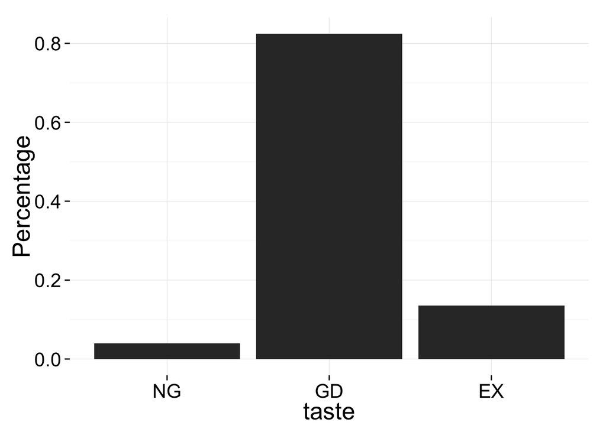

```r
ggplot(wdf, aes(x = taste)) +
  geom_bar(aes(y = (..count..)/sum(..count..))) +
  ylab('Percentage')
```

- NG : 4%
- GD : 82%
- EX : 14%

```r
summary(wdf$fixed.acidity)
```

```
##    Min. 1st Qu.  Median    Mean 3rd Qu.    Max.
##    4.60    7.10    7.90    8.32    9.20   15.90
```

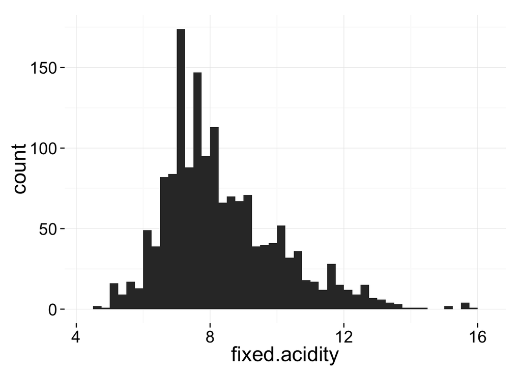

```r
qplot(x = fixed.acidity, data = wdf, binwidth=0.25)
```

Most wines have a fixed.acidity between 7 and 14.

```r
summary(wdf$volatile.acidity)
```

```
##    Min. 1st Qu.  Median    Mean 3rd Qu.    Max.
##  0.1200  0.3900  0.5200  0.5278  0.6400  1.5800
```

```
## stat_bin: binwidth defaulted to range/30. Use 'binwidth = x' to adjust this.
```

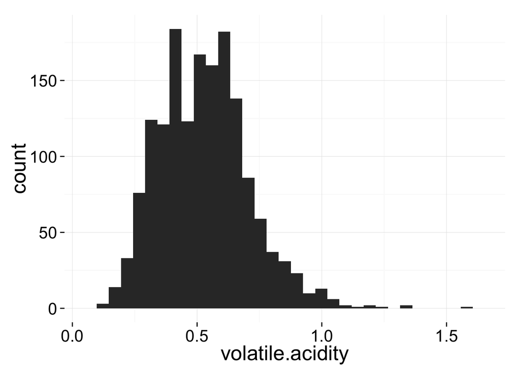

```r
qplot(x = volatile.acidity, data = wdf)
```

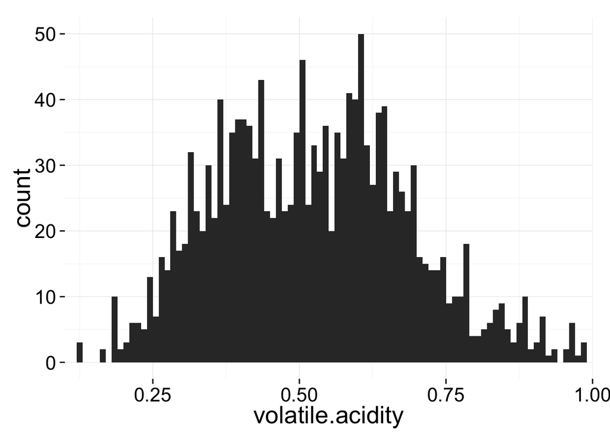

```r
qplot(x = volatile.acidity, data = wdf, binwidth=0.01) +
  coord_cartesian(xlim = c(0.1, 1.0))
```

Again, most of wines have a volatile.acidity between 0.2 and 1.0.

```r
summary(wdf$citric.acid)
```

```
##    Min. 1st Qu.  Median    Mean 3rd Qu.    Max.
##   0.000   0.090   0.260   0.271   0.420   1.000
```

```
## stat_bin: binwidth defaulted to range/30. Use 'binwidth = x' to adjust this.
```

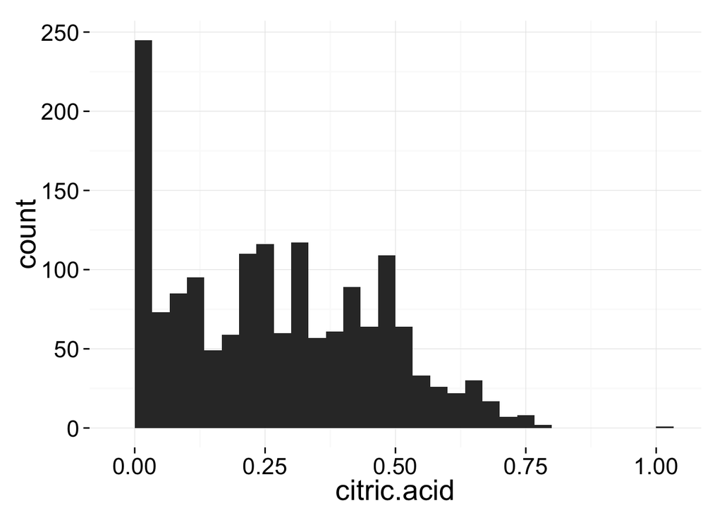

```r
qplot(x = citric.acid, data = wdf)
```

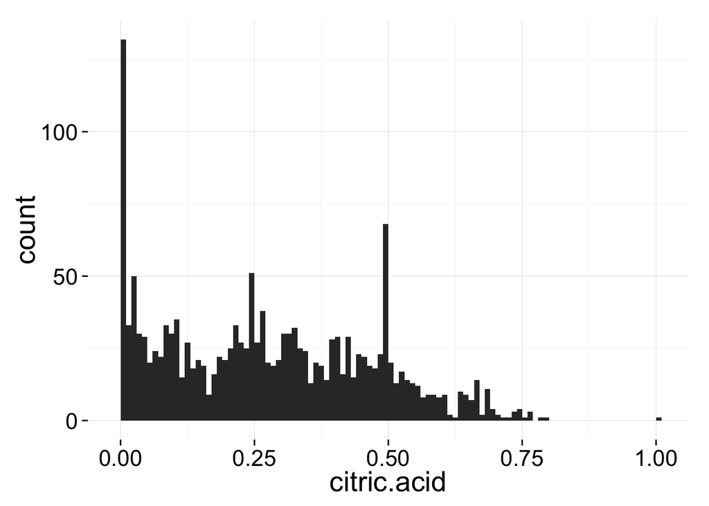

```r
qplot(x = citric.acid, data = wdf, binwidth=0.01)
```

```r
table(wdf$citric.acid == 0)
```

```
##
## FALSE  TRUE
##  1467   132
```

About 10% of wines have no citric.acid.

```r
summary(wdf$residual.sugar)
```

```
##    Min. 1st Qu.  Median    Mean 3rd Qu.    Max.
##   0.900   1.900   2.200   2.539   2.600  15.500
```

```
## stat_bin: binwidth defaulted to range/30. Use 'binwidth = x' to adjust this.
```

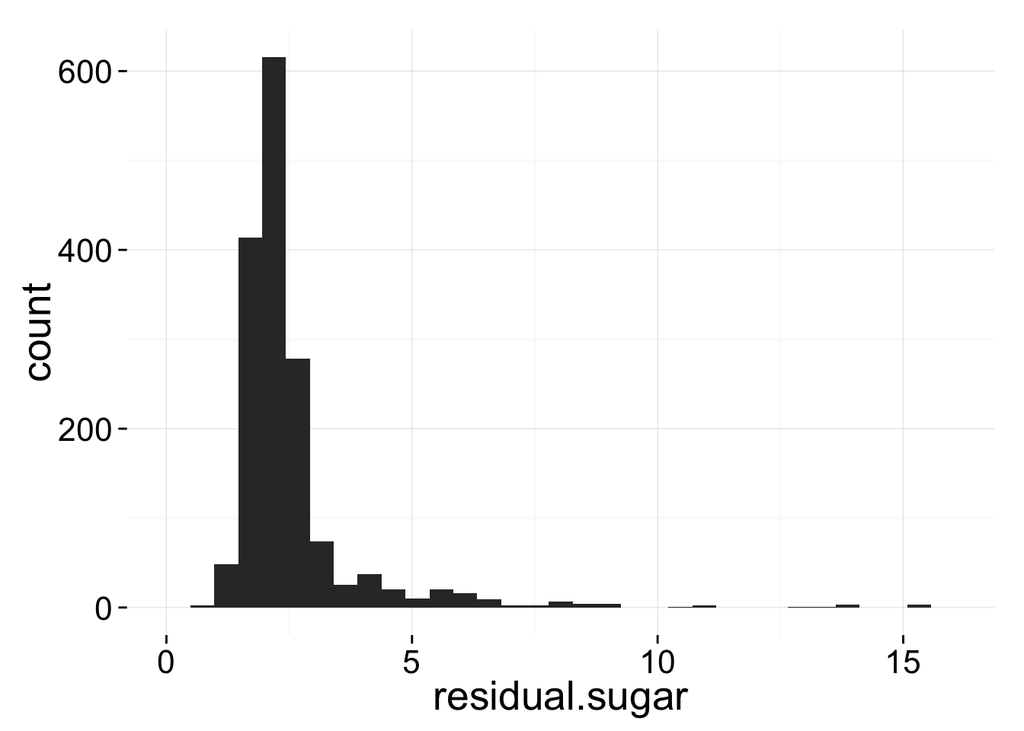

```r
qplot( x= residual.sugar, data = wdf)
```

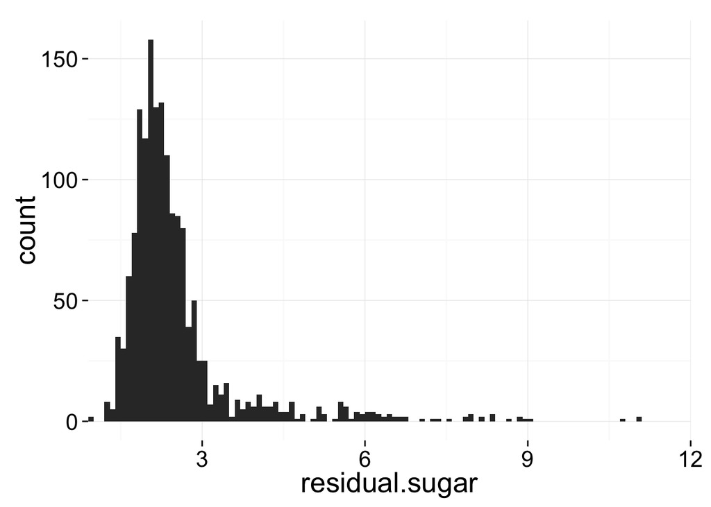

```r
qplot( x= residual.sugar, data = wdf, binwidth = 0.1) +
  coord_cartesian(xlim = c(0.9, 12.0))
```

Residual sugar of most wines varies from 1.0 to 7.0.

```r
summary(wdf$chlorides)
```

```
##    Min. 1st Qu.  Median    Mean 3rd Qu.    Max.
## 0.01200 0.07000 0.07900 0.08747 0.09000 0.61100
```

```
## stat_bin: binwidth defaulted to range/30. Use 'binwidth = x' to adjust this.
```

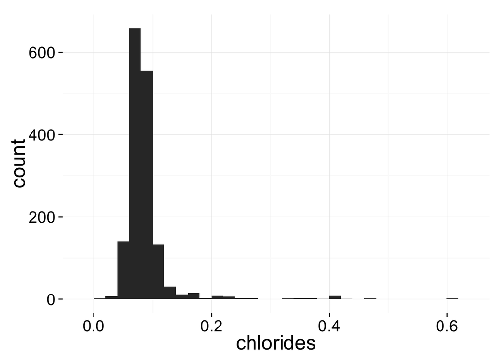

```r
qplot(x=chlorides, data = wdf)
```

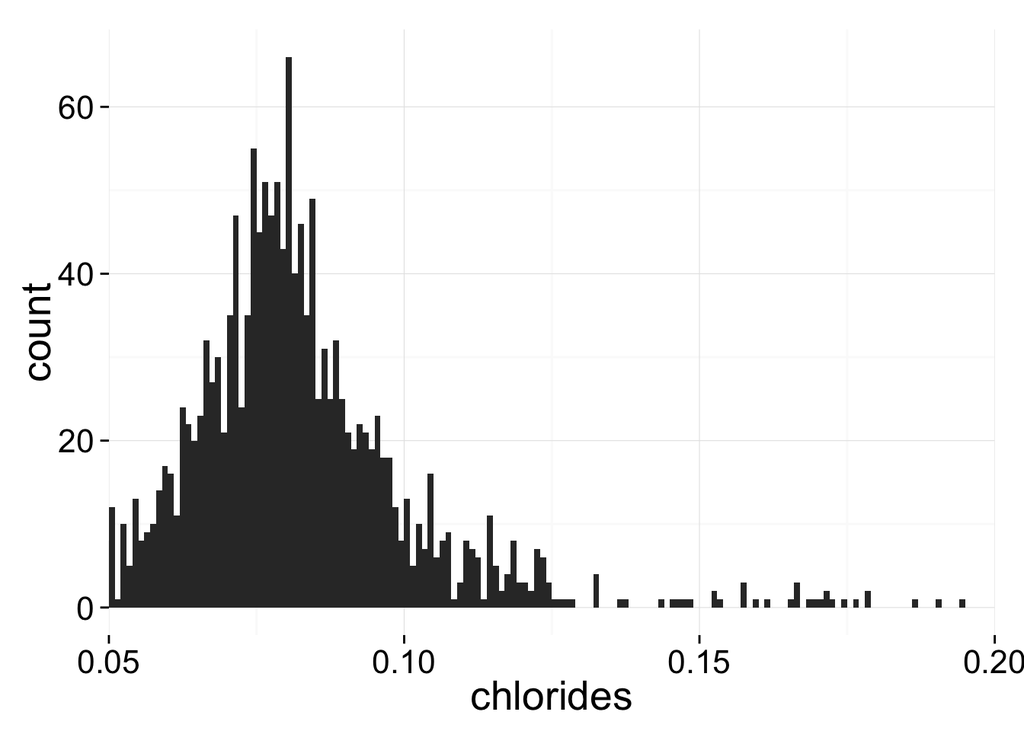

```r
qplot(x=chlorides, data = wdf, binwidth = 0.001) +
  coord_cartesian(xlim = c(0.05, 0.2))
```

Most wines have a chlorides ranging from 0.05 to 0.2.

```r
summary(wdf$free.sulfur.dioxide)
```

```
##    Min. 1st Qu.  Median    Mean 3rd Qu.    Max.
##    1.00    7.00   14.00   15.87   21.00   72.00
```

```
## stat_bin: binwidth defaulted to range/30. Use 'binwidth = x' to adjust this.
```

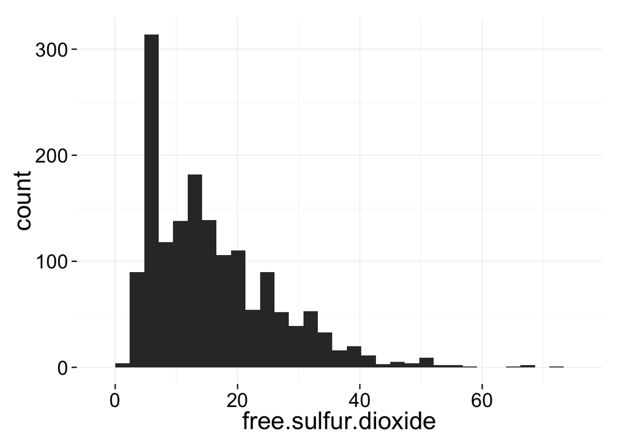

```r
qplot(x=free.sulfur.dioxide, data=wdf)
```

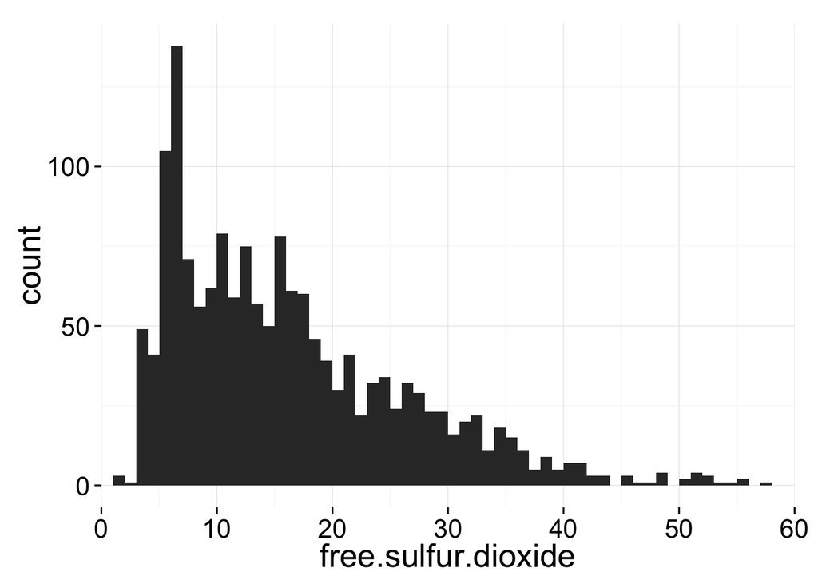

```r
qplot(x=free.sulfur.dioxide, data=wdf, binwidth=1) +
  coord_cartesian(xlim=c(0, 60))
```

Most wines have free.sulfur.dioxide under 40.

```r
summary(wdf$total.sulfur.dioxide)
```

```
##    Min. 1st Qu.  Median    Mean 3rd Qu.    Max.
##    6.00   22.00   38.00   46.47   62.00  289.00
```

```
## stat_bin: binwidth defaulted to range/30. Use 'binwidth = x' to adjust this.
```

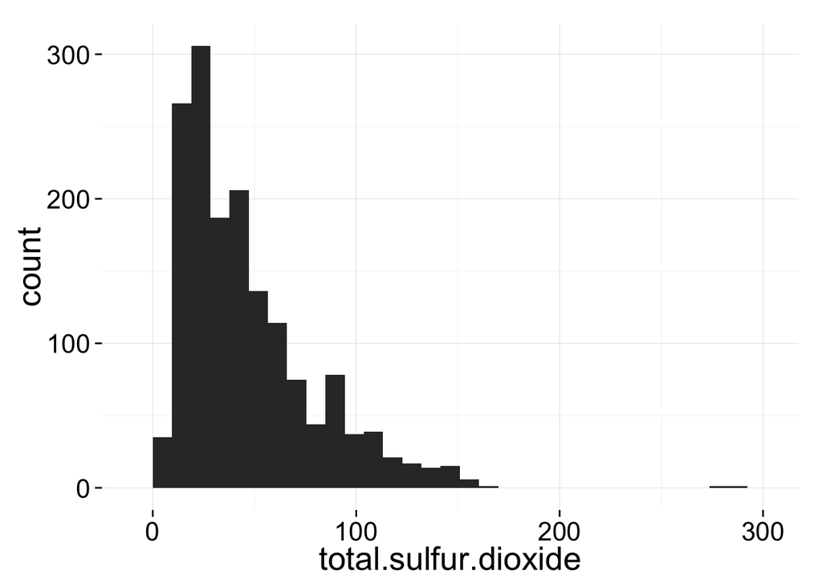

```r
qplot(x=total.sulfur.dioxide, data=wdf)
```

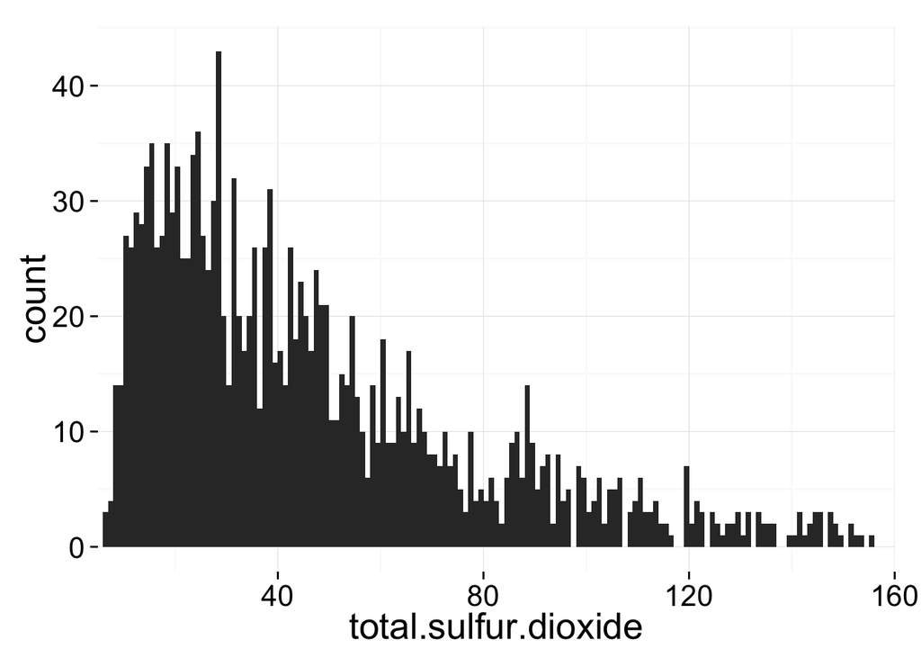

```r
qplot(x=total.sulfur.dioxide, data=wdf, binwidth = 1) +
  coord_cartesian(xlim=c(5, 160))
```

Again, most wine have total.sulfur.dioxide from 5 to 160.

```r
summary(wdf$density)
```

```
##    Min. 1st Qu.  Median    Mean 3rd Qu.    Max.
##  0.9901  0.9956  0.9968  0.9967  0.9978  1.0040
```

```
## stat_bin: binwidth defaulted to range/30. Use 'binwidth = x' to adjust this.
```

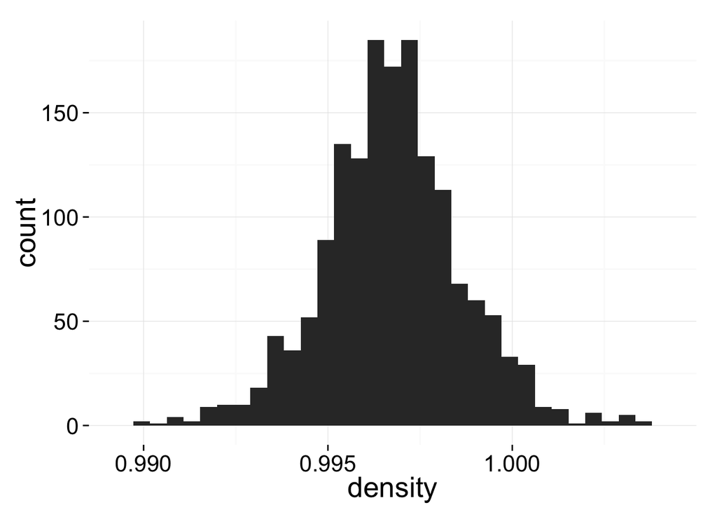

```r
qplot(x=density, data=wdf)
```

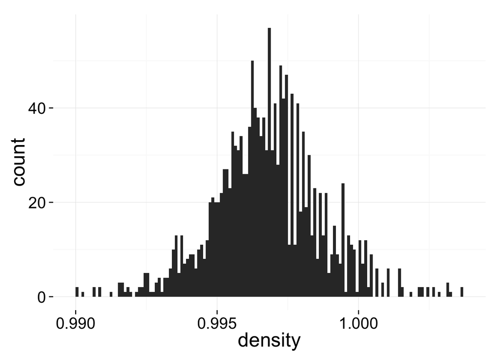

```r
qplot(x=density, data=wdf, binwidth=0.0001)
```

```r
var(wdf$density)
```

```
## [1] 3.562029e-06
```

Most wine have almost same density, because its variance is 3.5e-06, so small.

```r
summary(wdf$pH)
```

```
##    Min. 1st Qu.  Median    Mean 3rd Qu.    Max.
##   2.740   3.210   3.310   3.311   3.400   4.010
```

```
## stat_bin: binwidth defaulted to range/30. Use 'binwidth = x' to adjust this.
```

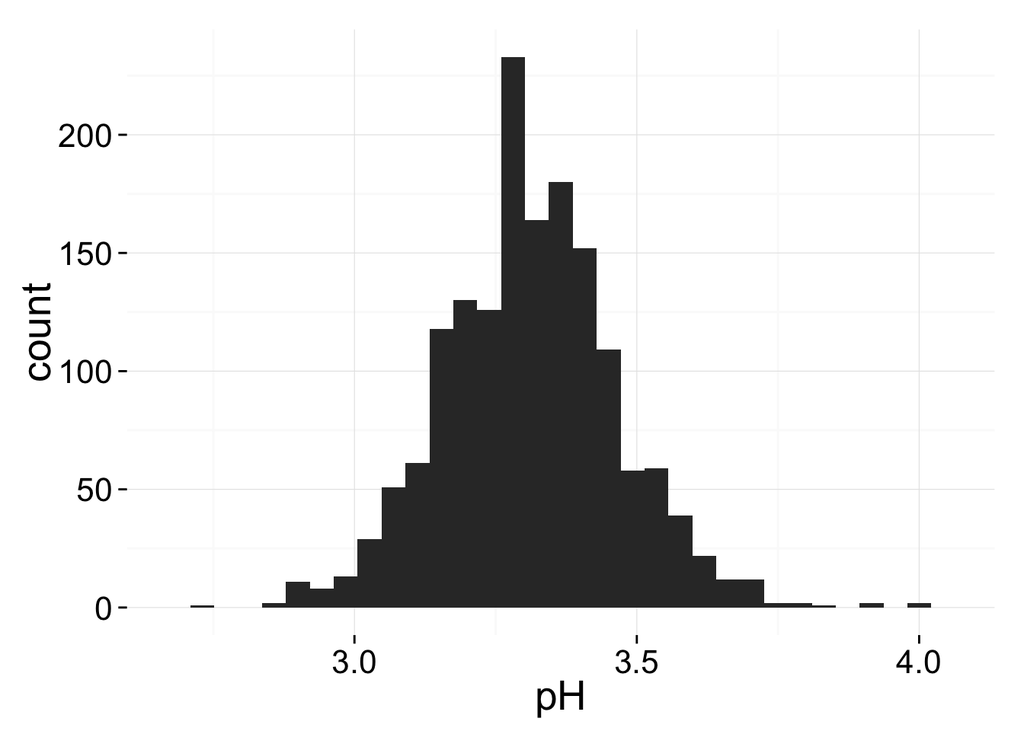

```r
qplot(x=pH, data=wdf)
```

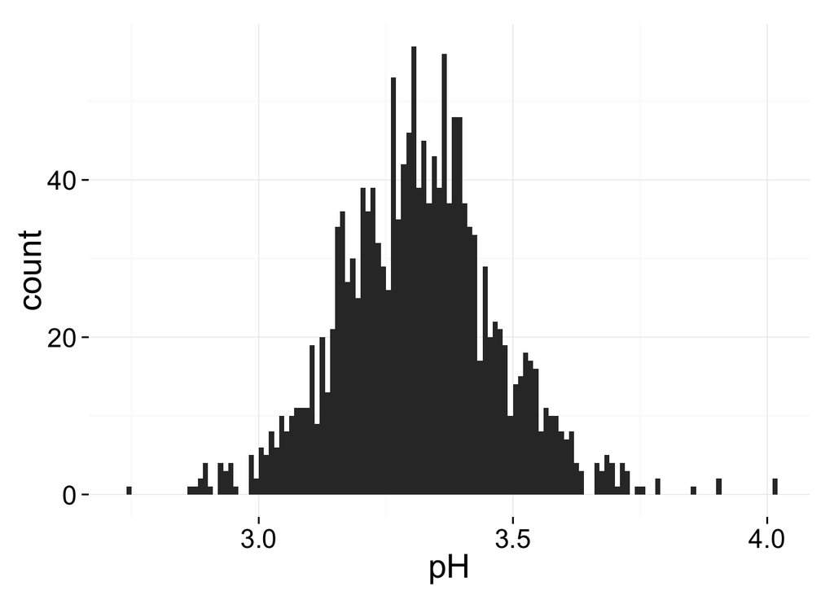

```r
qplot(x=pH, data=wdf, binwidth = 0.01)
```

```r
summary(wdf$sulphates)
```

```
##    Min. 1st Qu.  Median    Mean 3rd Qu.    Max.
##  0.3300  0.5500  0.6200  0.6581  0.7300  2.0000
```

```
## stat_bin: binwidth defaulted to range/30. Use 'binwidth = x' to adjust this.
```

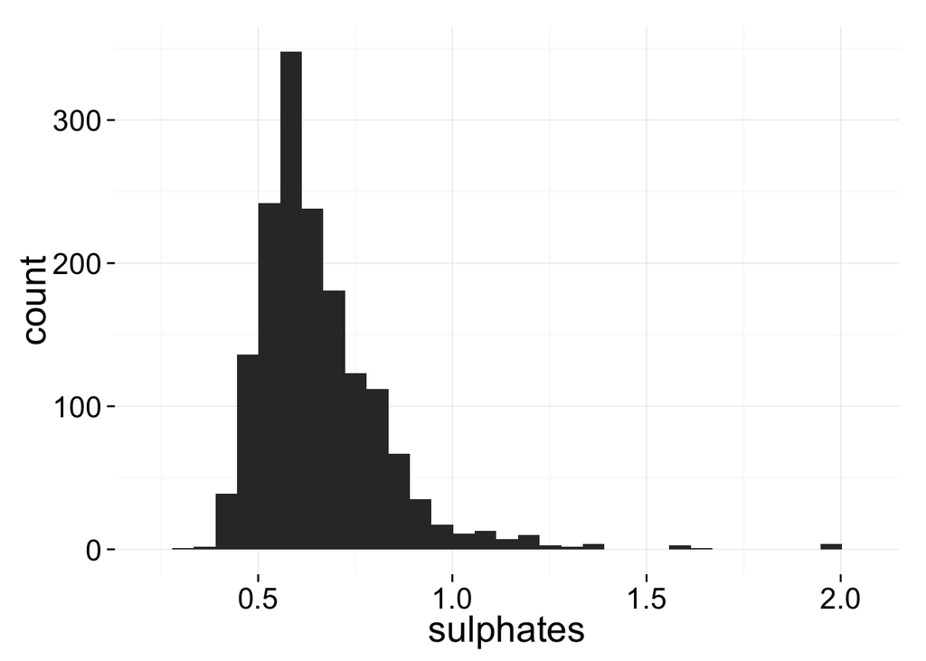

```r
qplot(x=sulphates, data=wdf)
```

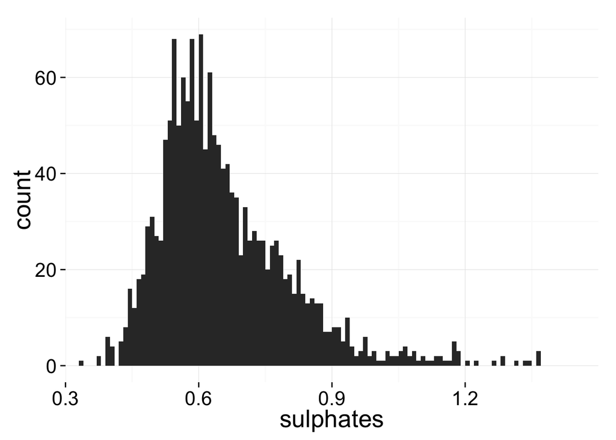

```r
qplot(x=sulphates, data=wdf, binwidth = 0.01) +
  coord_cartesian(xlim=c(0.3, 1.5))
```

Also, most wines’ sulphates have range from 0.3 to 1.2.

### What is/are the main feature(s) of interest in your dataset?

The main features in this data are alcohol, residual.sugar, and quality(taste). I want to verify that which features among alcohol and residual.sugar determine a wine’s better flavor.

### What other features in the dataset do you think will help support your investigation into your feature(s) of interest?

Some people enjoy citric.acid flavor, or density. Therefore, two features can be one of factors for good taste.

### Did you create any new variables from existing variables in the dataset?

I created a variable for ‘taste’ using quality variable. Because quality has only integer variable, so I think converting it to a categorical variable is good idea. In addition, I simplified 6 steps(3~8) to 3 steps(NG, GD, EX).

### Of the features you investigated, were there any unusual distributions? Did you perform any operations on the data to tidy, adjust, or change the form of the data? If so, why did you do this?

The quality variable is not tidy. It have just integer values. I think there is no need to use the feature as integer. So I decided to convert it to ordered factor with 3-levels.

# Bivariate Plots Section

[output not shown]

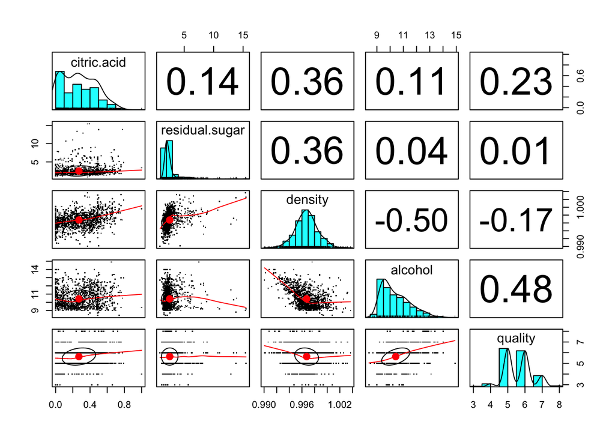

```r
set.seed(10)
pairs.panels(wdf[, c(3, 4, 8, 11, 12)], pch=".")
```

The alcohol feature has the most impact to quality. It is not ideal correlation, but it is quite high. Interesting thing is that residual.sugar is not correlated with quality. That menas the sweet wine doesn’t implies better flavored wine.

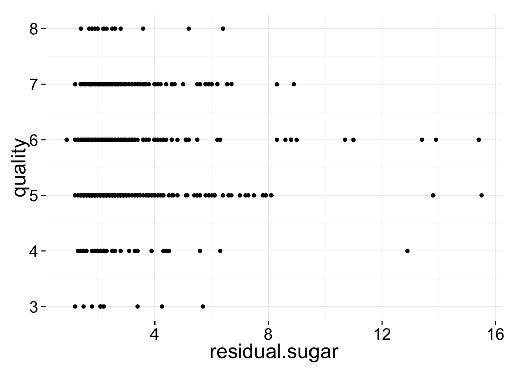

```r
qplot(x=residual.sugar, y=quality, data=wdf)
```

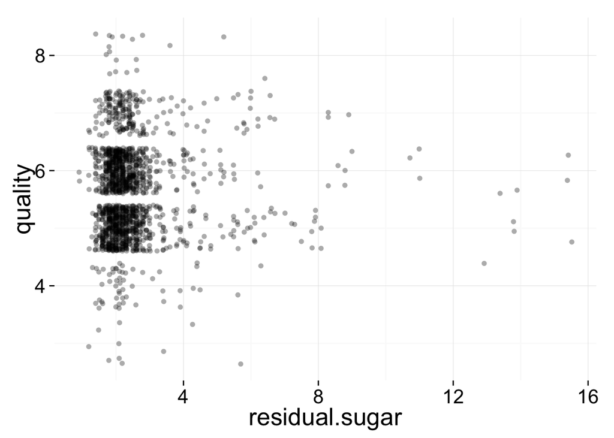

```r
ggplot(aes(x=residual.sugar, y=quality), data=wdf) +
  geom_jitter(alpha = 0.33)
```

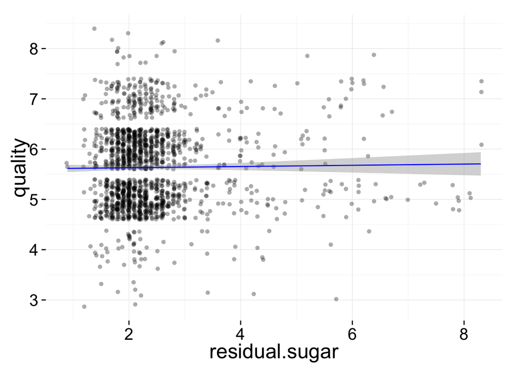

```r
ggplot(aes(x=residual.sugar, y=quality), data=subset(wdf, residual.sugar > 0 & residual.sugar <= quantile(wdf$residual.sugar, 0.99))) +
  geom_jitter(alpha = 0.33) +
  geom_smooth(method = 'lm', se = T, color = 'blue')
```

Actually, residual.sugar cannot show a tendecy with quality feature. It turns out that sugar and quality don’t have much relationship.

```r
sugarAndQuality <- lm(quality ~ residual.sugar,
                    data=subset(wdf, residual.sugar > 0 & residual.sugar <= quantile(wdf$residual.sugar, 0.99)))
summary(sugarAndQuality)
```

```
##
## Call:
## lm(formula = quality ~ residual.sugar, data = subset(wdf, residual.sugar >
##     0 & residual.sugar <= quantile(wdf$residual.sugar, 0.99)))
##
## Residuals:
##     Min      1Q  Median      3Q     Max
## -2.6743 -0.6319  0.3560  0.3717  2.3778
##
## Coefficients:
##                Estimate Std. Error t value Pr(>|t|)
## (Intercept)     5.60528    0.05277 106.220   <2e-16 ***
## residual.sugar  0.01211    0.01993   0.608    0.544
## ---
## Signif. codes:  0 '***' 0.001 '**' 0.01 '*' 0.05 '.' 0.1 ' ' 1
##
## Residual standard error: 0.809 on 1581 degrees of freedom
## Multiple R-squared:  0.0002335,  Adjusted R-squared:  -0.0003989
## F-statistic: 0.3692 on 1 and 1581 DF,  p-value: 0.5435
```

R^2 describes that sugar and quality have almost zero relationship.

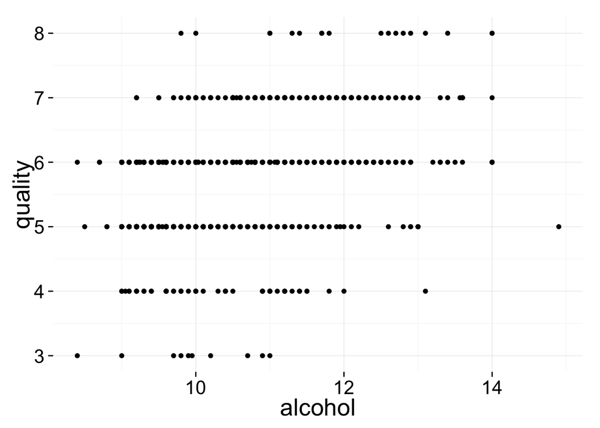

```r
qplot(x=alcohol, y=quality, data=wdf)
```

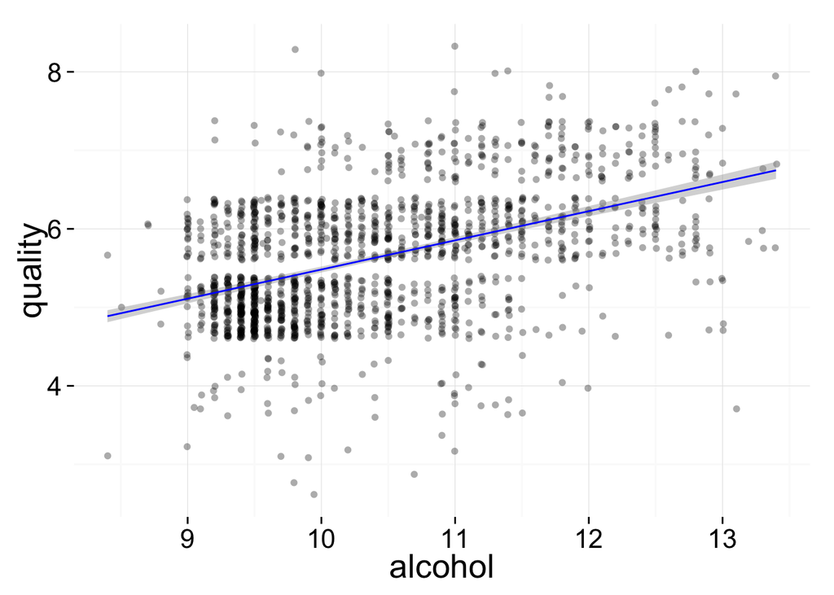

```r
ggplot(aes(x=alcohol, y=quality), data=subset(wdf, alcohol > 0 & alcohol <= quantile(wdf$alcohol, 0.99))) +
  geom_jitter(alpha = 0.33) +
  geom_smooth(method = 'lm', se = T, color = 'blue')
```

This plot shows a tendency syaing that the more alcohol, the higer quality values.

```r
alcholAndQuality <- lm(quality ~ alcohol,
                    data=subset(wdf, alcohol > 0 & alcohol <= quantile(wdf$alcohol, 0.99)))
summary(alcholAndQuality)
```

```
##
## Call:
## lm(formula = quality ~ alcohol, data = subset(wdf, alcohol >
##     0 & alcohol <= quantile(wdf$alcohol, 0.99)))
##
## Residuals:
##     Min      1Q  Median      3Q     Max
## -2.8535 -0.4077 -0.1848  0.5180  2.5923
##
## Coefficients:
##             Estimate Std. Error t value Pr(>|t|)
## (Intercept)  1.76698    0.18234   9.691   <2e-16 ***
## alcohol      0.37150    0.01746  21.275   <2e-16 ***
## ---
## Signif. codes:  0 '***' 0.001 '**' 0.01 '*' 0.05 '.' 0.1 ' ' 1
##
## Residual standard error: 0.708 on 1583 degrees of freedom
## Multiple R-squared:  0.2224, Adjusted R-squared:  0.2219
## F-statistic: 452.6 on 1 and 1583 DF,  p-value: < 2.2e-16
```

R^2 value is 0.22, that means alcohol explains about 22% of the wine quality.

# Bivariate Analysis

### Talk about some of the relationships you observed in this part of the investigation. How did the feature(s) of interest vary with other features in the dataset?

### Did you observe any interesting relationships between the other features (not the main feature(s) of interest)?

### What was the strongest relationship you found?

# Multivariate Plots Section

# Multivariate Analysis

### Talk about some of the relationships you observed in this part of the investigation. Were there features that strengthened each other in terms of looking at your feature(s) of interest?

### Were there any interesting or surprising interactions between features?

### OPTIONAL: Did you create any models with your dataset? Discuss the strengths and limitations of your model.

# Final Plots and Summary

### Plot One

### Description One

### Plot Two

### Description Two

### Plot Three

### Description Three

# Reflection